# Time Series with data.table in R

Amit Agni

22/02/2019

### Chapter 1 : Review of data.table

- Selecting columns with names stored in a vector is a powerful tool to know.
- get() - takes in string, and returns the values inside object
- Using {}
- set .. functions
- Creating and selecting columns with variables means you can pass new data through your code without needing to copy and paste common operations.
- Complete add_interaction(), which should take two column names and produce a new column that holds the result of multiplying the two columns together.

```r
vec <- c("asdasd","sdsds","sdsds")
get("vec")
```

```
## [1] "asdasd" "sdsds"  "sdsds"
```

```r
add_interaction <- function(someDT, col1, col2){
    new_col_name <- paste0(col1, "_times_", col2)
    someDT[, (new_col_name) := get(col1) * get(col2)]
}
```

- scale_by_10() should select a column, multiply it by 10, and store the result in a new column. Use this function to scale the engine temperature column by 10. Call the new column “temp10”.

> The fact that the := operator changes the data.table in place also greatly reduces the risk that you’ll blow out your memory.

```r
# Write a function to scale a column by 10
#Use () to the left of the := to ensure you get a new column named by whatever string is in new_col_name.
#Use get() to the right of the := to select the column named by the current value of col_to_scale.

# Write a function to scale a column by 10
scale_by_10 <- function(someDT, col_to_scale, new_col_name){
    someDT[, (new_col_name) := get(col_to_scale) * 10]
}

# Try it out

#scale_by_10(diagnosticDT, col_to_scale = "engine_temp", new_col_name = "temp10")

# Check the state of the data.table
#head(diagnosticDT)
```

Write a function that squares every numeric column

```r
# Write a function that squares every numeric column
add_square_features <- function(someDT, cols){
    for (col_name in cols){
        new_col_name <- paste0(col_name,"_squared")
        someDT[, (new_col_name) := get(col_name) ^ 2 ]
    }
}

# Look at the difference!
#add_square_features(diagnosticDT,c("engine_speed","engine_temp","system_voltage"))

#head(diagnosticDT)
```

**setnames**

- Complete tag_numeric_cols(). This function should take in a data.table and a vector of column names, and add _NUMERIC to the end of those columns.

> Did you notice that the function you wrote didn’t return anything? The fact that you used in-place modification means that this will be fast even on very large data tables.

```r
# Tag all the numeric columns with "_NUMERIC"
tag_numeric_cols <- function(DT, cols){
    setnames(DT, old = cols, new = paste0(cols, "_NUMERIC"))
}

v<-c(TRUE,FALSE)
names(mtcars)[v]
```

```
## [1] "mpg"  "disp" "drat" "qsec" "am"   "carb"
```

**functions inside DT**

The correlations() function is meant to take in a data.table and return a correlation matrix of all the numeric columns.

```r
# Mean of engine temp
#diagnosticDT[, mean(engine_temp)]

# Correlation between engine_temp and system_voltage
#diagnosticDT[, cor(engine_temp, system_voltage)]

# Get classes of column names
correlations <- function(DT){
    # Find numeric columns
    num_cols <- DT[, sapply(.SD, is.numeric)]
    numeric_cols <- names(DT)[num_cols]
    return(DT[, cor(.SD), .SDcols = numeric_cols])
}

# Function to get correlation matrix from a data.table
corrmat_from_dt <- function(DT){
    numeric_cols <- get_numeric_cols(DT)
    return(DT[, cor(.SD), .SDcols = numeric_cols])
}
```

### Chapter 2 : Getting ts data into data.table

**Overview of POSIXct type**

- POSIXlt stores dates in human readable form
- POSIXct - signed integer representing seconds since 01-01-1970 with a single attribute for tz

> The origin argument expects a string date in a format like “2000-01-01”. Recall that Excel-format dates need to be converted to R Date objects before you can turn them into POSIXct objects.

```r
# Create POSIXct dates from a hypothetical Excel dataset
#excelDT[, posix := as.POSIXct(as.Date(timecol, origin = "1900-01-01"), tz = "UTC")]

# Convert strings to POSIXct
#stringDT[, posix := as.POSIXct(timecol, tz = "UTC")]

# Convert epoch seconds to POSIXct
#epochSecondsDT[, posix := as.POSIXct(timecol, tz = "UTC", origin = "1970-01-01")]

# Convert epoch milliseconds to POSIXct
#epochMillisDT[, posix := as.POSIXct(timecol / 1000, tz = "UTC", origin = "1970-01-01")]
```

**Creating data.tables from vectors**

```r
# Generate sample IoT data
iotDT <- data.table(
    timestamp = seq.POSIXt(as.POSIXct("2016-04-19 00:00:00"), as.POSIXct("2016-04-20 00:00:00"), length.out = 25),
    engine_temp = rnorm(n = 25),
    ambient_temp = rnorm(n = 25)
)
head(iotDT)
```

```
##              timestamp engine_temp ambient_temp
## 1: 2016-04-19 00:00:00   1.0914134  -0.21755812
## 2: 2016-04-19 01:00:00  -0.9733288  -1.81518651
## 3: 2016-04-19 02:00:00   0.7470943  -0.02666309
## 4: 2016-04-19 03:00:00   2.6683306  -0.55677264
## 5: 2016-04-19 04:00:00  -0.6643133   0.70644155
## 6: 2016-04-19 05:00:00  -1.7425456   0.29652726
```

**Coercing from xts**

> Brief overview of xts : Unlike a data.frame, a flat data representation with no concept of special-purpose columns, an xts object is a complex object that separates out the main time component, or index, from all other observations.

```r
# Simulated data
some_data <- rnorm(100)
some_dates <- seq.POSIXt(
  from = as.POSIXct("2017-06-15 00:00:00Z", tz = "UTC"),
  to = as.POSIXct("2017-06-15 01:00:00Z", tz = "UTC"),
  length.out = 100
)

# Make your own 'xts' object
myXTS <- xts::xts(x = some_data, order.by = some_dates)

# View the timezone
print(attr(myXTS, "tzone"))
```

```
## [1] "UTC"
```

**Why does anyone use xts for time series data?**

> xts has some really cool functionality that was originally designed with financial data in mind. For example, xts allows you to use human-readable dates to subset the data. In addition, for unevenly-spaced time series it’s trivial to create windowed simple aggregations. Try running xts::to.hourly(nickelXTS).

```r
#Create fifteenXTS, an xts object that holds the final 15 minutes of that hour.
#fifteenXTS <- nickelXTS['2018-01-01 00:45:00/']

#Generate 10-minute aggregations of nickel prices.
#tenMinuteXTS <- xts::to.minutes10(nickelXTS)

#Get similar aggregations at the 1-minute frequency`.
#oneMinuteXTS <- xts::to.minutes(nickelXTS)
```

**Combining datasets with merge and rbindlist**

- use round() if ts columns are different
- rbindlist()

### Chapter 3 : Generating lags, differences, and windowed aggregations

**Generating lags**

- shift()
- setorderv() - use before shift()
- stargazer package

```r
# Add 1-period and 2-period lags
#aluminumDT[, lag1 := shift(price, type = "lag", n = 1)]
#aluminumDT[, lag2 := shift(price, type = "lag", n = 2)]

# Fit models with 1 and 2 lags
#mod1 <- lm(price ~ lag1, data = aluminumDT)
#mod2 <- lm(price ~ lag1 + lag2, data = aluminumDT)

# Compare
#stargazer::stargazer(list(mod1, mod2), type = "text")
```

**Growth rates and differences**

- Differencing
  - Stationary forms - any 2 chosen periods will have same mean and variance
- Growth rates : ratio - 1

**windowing with j and by**

- Generate a new column called “hour_end” that holds an indicator for the hour bucket each date-time falls into.
- data.table’s j clause can be used to apply functions to data. Combining by and floor(), we can generate fixed-window aggregates such as “1-day average”!
- Windowed aggregations are incredibly valuable in doing data science with time series data. They can be used to downsample high-frequency data so plotting code doesn’t make your computer explode.

```r
#seconds_in_an_hour <- 60 * 60
#passengerDT[, hour_end := floor(obs_time_in_seconds / seconds_in_an_hour)]

#Use .N and group on asset to confirm that this worked. Since the data are collected every 15 minutes, you should see 4 observations in each hour.
```

### Chapter 4 : Case Study - modeling metal prices

**Merging five tables into one using Reduce()**

```r
# Merge five tables into one
# mergedDT <- Reduce(
#     f = function(x, y){
#         merge(x, y, all = TRUE, by = "close_date")
#     },
#     x = list(aluminumDT, copperDT, cobaltDT, nickelDT, tinDT)
# )
```

**Time Series feature engg** * **When DT is passed to a function, it is passed as a reference and not as a copy of object**

- implement add_diffs(), a function to generate first differences and add them to a time series dataset!
- grep() to find columns containing _price

```r
# Function to add differences
add_diffs <- function(DT, cols, ndiff){
    for (colname in cols){
        new_name <- paste0(colname, "_diff", ndiff)
        DT[, (new_name) := get(colname) - shift(get(colname), type = "lag", n = ndiff)]
    }
}

#grep(pattern = "_price",x=names(metalsDT),value = TRUE)

# Function to add growth rates
add_growth_rates <- function(DT, cols, ndiff){
    for (colname in cols){
        new_name <- paste0(colname, "_pctchg", ndiff)
        DT[, (new_name) := (get(colname) / shift(get(colname), type = "lag", n = ndiff)) - 1]
    }
}


# Function to get correlation matrix from a data.table
corrmat_from_dt <- function(DT, cols){
    # Subset to the requested columns
    subDT <- DT[, .SD, .SDcols = cols]

    # Drop NAs
    subDT <- subDT[complete.cases(subDT)]

    return(cor(subDT))
}
```

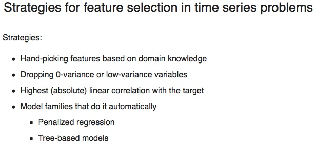

# Summary